# Run splicing cluster assignment, splicing burden, gsva, CLK1

Ryan Corbett, adapted by Jo Lynne Rokita for CLK1

2024

**Purpose:**

Runs survival analysis models using splicing cluster assignment and 1) single exon splicing burden index (SBI) 2) KEGG Spliceosome GSVA scores or 3) CLK1 exon 4 TPM as a predictor

## Usage

Uses a wrapper function (`survival_analysis`) from utils folder.

## Setup

#### Packages and functions

Load packages, set directory paths and call setup script

```r
library(tidyverse)
library(survival)
library(ggpubr)
library(ggplot2)
library(patchwork)

root_dir <- rprojroot::find_root(rprojroot::has_dir(".git"))

data_dir <- file.path(root_dir, "data")
analysis_dir <- file.path(root_dir, "analyses", "survival")
input_dir <- file.path(analysis_dir, "results")
results_dir <- file.path(analysis_dir, "results")
plot_dir <- file.path(analysis_dir, "plots")

# If the input and results directories do not exist, create it
if (!dir.exists(results_dir)) {
  dir.create(results_dir, recursive = TRUE)
}

source(file.path(analysis_dir, "util", "survival_models.R"))
```

Set metadata and cluster assignment file paths

```r
metadata_file <- file.path(input_dir, "splicing_indices_with_survival.tsv")

cluster_file <- file.path(root_dir, "analyses",
                          "sample-psi-clustering", "results",
                          "sample-cluster-metadata-top-5000-events-stranded.tsv")

kegg_scores_stranded_file <- file.path(root_dir, "analyses",
                          "sample-psi-clustering", "results",
                          "gsva_output_stranded.tsv")

tpm_file <- file.path(data_dir, "rna-isoform-expression-rsem-tpm.rds")
clk1_psi_file <- file.path(root_dir,
                           "analyses",
                           "CLK1-splicing_correlations",
                           "results",
                           "clk1-exon4-proportion.tsv")
```

Wrangle data Add cluster assignment and spliceosome gsva scores to `metadata` and define column `lgg_group` (LGG or non_LGG)

```r
metadata <- read_tsv(metadata_file)
clusters <- read_tsv(cluster_file) %>%
  dplyr::rename(Kids_First_Biospecimen_ID = sample_id)
clk1_psi <- read_tsv(clk1_psi_file) %>%
  dplyr::rename(CLK1_ex4_PSI = proportion) %>%
  select(-plot_group)
gsva_scores <- read_tsv(kegg_scores_stranded_file) %>%
  dplyr::filter(geneset == "KEGG_SPLICEOSOME") %>%
  dplyr::rename(spliceosome_gsva_score = score)
all_clk4_transcr_counts <- readRDS(tpm_file) %>%
  filter(grepl("^CLK1", gene_symbol)) %>%
  mutate(
    transcript_id = case_when(
      transcript_id %in% c("ENST00000321356.9", "ENST00000434813.3", "ENST00000409403.6") ~ "Exon 4",
#      transcript_id == "ENST00000321356.9" ~ "Exon 4",
      TRUE ~ "Other"
    )
  ) %>%
  group_by(transcript_id) %>%
  summarise(across(starts_with("BS"), sum, na.rm = TRUE)) %>%
  pivot_longer(cols = -transcript_id, names_to = "Kids_First_Biospecimen_ID", values_to = "CLK1_Ex4_TPM") %>%
  filter(transcript_id == "Exon 4") %>%
  inner_join(clusters, by = "Kids_First_Biospecimen_ID") %>%
  left_join(clk1_psi)
# how many clusters?
n_clust <- length(unique(clusters$cluster))

metadata <- metadata %>%
  right_join(all_clk4_transcr_counts %>% dplyr::select(Kids_First_Biospecimen_ID,
                                       cluster, CLK1_Ex4_TPM, CLK1_ex4_PSI)) %>%
  left_join(gsva_scores %>% dplyr::select(sample_id,
                                          spliceosome_gsva_score),
            by = c("Kids_First_Biospecimen_ID" = "sample_id")) %>%
  dplyr::mutate(cluster = glue::glue("Cluster {cluster}")) %>%
  dplyr::mutate(cluster = fct_relevel(cluster,
                                               paste0("Cluster ", 1:n_clust))) %>%
  dplyr::mutate(lgg_group = case_when(
    Histology == "Low-grade glioma" ~ "LGG",
    TRUE ~ "non-LGG"
  )) %>%
  dplyr::mutate(SBI_SE = SI_SE * 10) %>%
  dplyr::mutate(age_at_diagnosis_years = age_at_diagnosis_days/365.25)
```

Generate coxph models including extent of tumor resection, lgg group, cluster assignment, SBI, and CLK1 exon 4 TPM as covariates

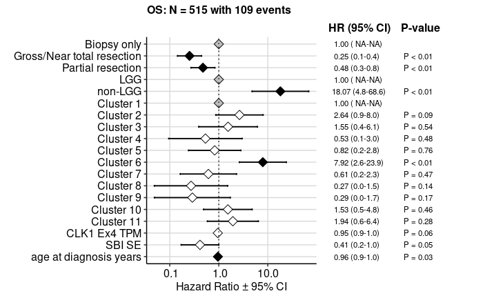

```r
add_model_os <- fit_save_model(metadata[!metadata$extent_of_tumor_resection %in% c("Not Reported", "Unavailable"),],
                              terms = "extent_of_tumor_resection+lgg_group+cluster+age_at_diagnosis_years+SBI_SE+CLK1_Ex4_TPM",
                               file.path(results_dir, "cox_OS_additive_terms_resection_lgg_group_cluster_SBI_CLK1_Ex4_TPM.RDS"),
                               "multivariate",
                               years_col = "OS_years",
                               status_col = "OS_status")

forest_os <- plotForest(readRDS(file.path(results_dir, "cox_OS_additive_terms_resection_lgg_group_cluster_SBI_CLK1_Ex4_TPM.RDS")))
```

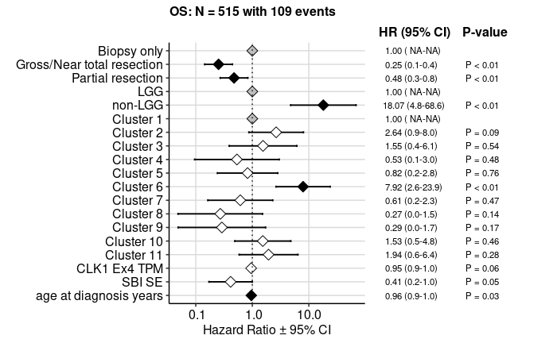

```r
forest_os

ggsave(file.path(plot_dir, "forest_add_OS_resection_lgg_group_cluster_assignment_SBI_CLK1_Ex4_TPM.pdf"),
       forest_os,
       width = 10, height = 6, units = "in",
       device = "pdf")
```

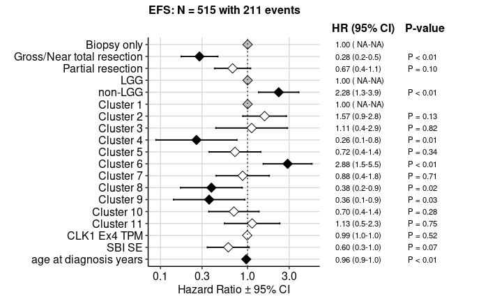

```r
add_model_efs <- fit_save_model(metadata[!metadata$extent_of_tumor_resection %in% c("Not Reported", "Unavailable"),],
                              terms = "extent_of_tumor_resection+lgg_group+cluster+age_at_diagnosis_years+SBI_SE+CLK1_Ex4_TPM",
                               file.path(results_dir, "cox_EFS_additive_terms_resection_lgg_group_cluster_SBI_CLK1_Ex4_TPM.RDS"),
                               "multivariate",
                               years_col = "EFS_years",
                               status_col = "EFS_status")

forest_efs <- plotForest(readRDS(file.path(results_dir, "cox_EFS_additive_terms_resection_lgg_group_cluster_SBI_CLK1_Ex4_TPM.RDS")))
```

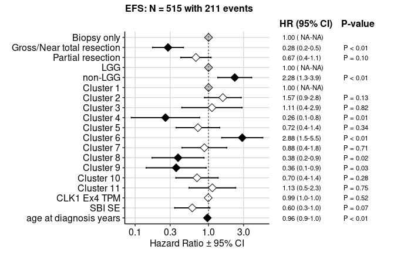

```r
forest_efs

ggsave(file.path(plot_dir, "forest_add_EFS_resection_lgg_group_cluster_assignment_SBI_CLK1_Ex4_TPM.pdf"),
       forest_efs,
       width = 10, height = 6, units = "in",
       device = "pdf")
```

repeat analysis with CLK1 exon 4 TPM alone

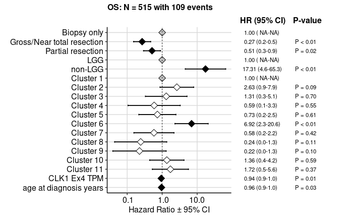

```r
add_model_os <- fit_save_model(metadata[!metadata$extent_of_tumor_resection %in% c("Not Reported", "Unavailable"),],
                              terms = "extent_of_tumor_resection+lgg_group+cluster+age_at_diagnosis_years+CLK1_Ex4_TPM",
                               file.path(results_dir, "cox_OS_additive_terms_resection_lgg_group_cluster_CLK1_Ex4_TPM.RDS"),
                               "multivariate",
                               years_col = "OS_years",
                               status_col = "OS_status")

forest_os <- plotForest(readRDS(file.path(results_dir, "cox_OS_additive_terms_resection_lgg_group_cluster_CLK1_Ex4_TPM.RDS")))
```

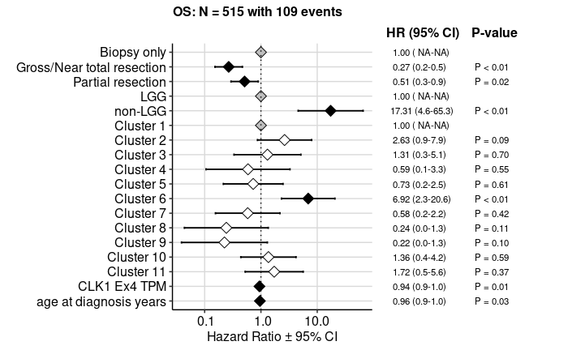

```r
forest_os

ggsave(file.path(plot_dir, "forest_add_OS_resection_lgg_group_cluster_assignment_CLK1_Ex4_TPM.pdf"),
       forest_os,
       width = 10, height = 6, units = "in",
       device = "pdf")
```

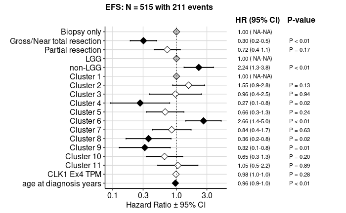

```r
add_model_efs <- fit_save_model(metadata[!metadata$extent_of_tumor_resection %in% c("Not Reported", "Unavailable"),],
                              terms = "extent_of_tumor_resection+lgg_group+cluster+age_at_diagnosis_years+CLK1_Ex4_TPM",
                               file.path(results_dir, "cox_EFS_additive_terms_resection_lgg_group_cluster_CLK1_Ex4_TPM.RDS"),
                               "multivariate",
                               years_col = "EFS_years",
                               status_col = "EFS_status")

forest_efs <- plotForest(readRDS(file.path(results_dir, "cox_EFS_additive_terms_resection_lgg_group_cluster_CLK1_Ex4_TPM.RDS")))
```

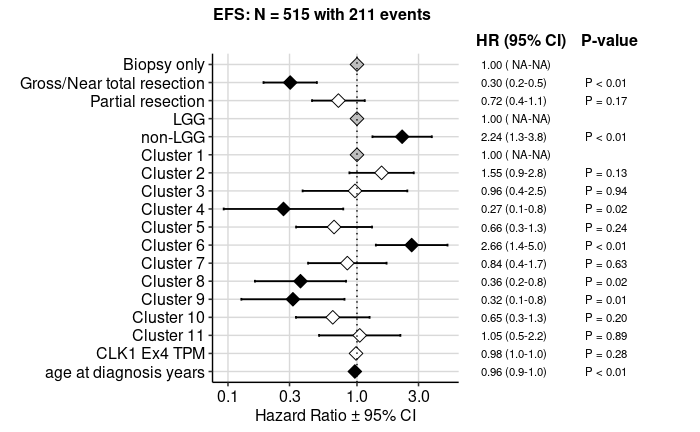

```r
forest_efs

ggsave(file.path(plot_dir, "forest_add_EFS_resection_lgg_group_cluster_assignment_CLK1_Ex4_TPM.pdf"),
       forest_efs,
       width = 10, height = 6, units = "in",
       device = "pdf")
```

```r
NA
NA
```

repeat analysis with CLK1 exon 4 PSI

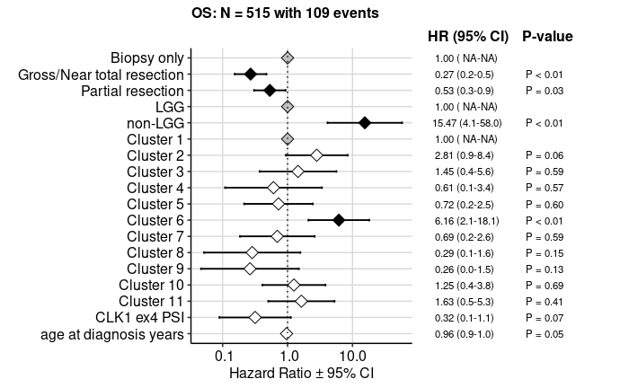

```r
add_model_os <- fit_save_model(metadata[!metadata$extent_of_tumor_resection %in% c("Not Reported", "Unavailable"),],
                              terms = "extent_of_tumor_resection+lgg_group+cluster+age_at_diagnosis_years+CLK1_ex4_PSI",
                               file.path(results_dir, "cox_OS_additive_terms_resection_lgg_group_cluster_CLK1_ex4_PSI.RDS"),
                               "multivariate",
                               years_col = "OS_years",
                               status_col = "OS_status")

forest_os <- plotForest(readRDS(file.path(results_dir, "cox_OS_additive_terms_resection_lgg_group_cluster_CLK1_ex4_PSI.RDS")))
```

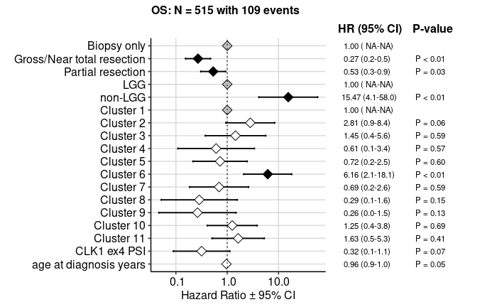

```r
forest_os

ggsave(file.path(plot_dir, "forest_add_OS_resection_lgg_group_cluster_assignment_CLK1_ex4_PSI.pdf"),
       forest_os,
       width = 10, height = 6, units = "in",
       device = "pdf")
```

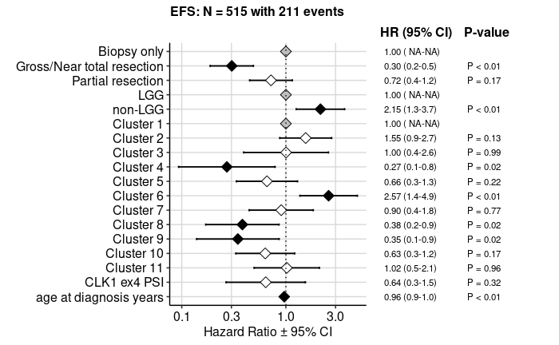

```r
add_model_efs <- fit_save_model(metadata[!metadata$extent_of_tumor_resection %in% c("Not Reported", "Unavailable"),],
                              terms = "extent_of_tumor_resection+lgg_group+cluster+age_at_diagnosis_years+CLK1_ex4_PSI",
                               file.path(results_dir, "cox_EFS_additive_terms_resection_lgg_group_cluster_CLK1_ex4_PSI.RDS"),
                               "multivariate",
                               years_col = "EFS_years",
                               status_col = "EFS_status")

forest_efs <- plotForest(readRDS(file.path(results_dir, "cox_EFS_additive_terms_resection_lgg_group_cluster_CLK1_ex4_PSI.RDS")))
```

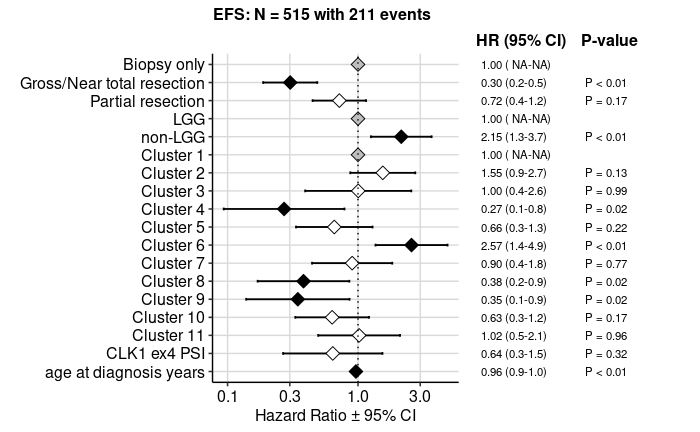

```r
forest_efs

ggsave(file.path(plot_dir, "forest_add_EFS_resection_lgg_group_cluster_assignment_CLK1_ex4_PSI.pdf"),
       forest_efs,
       width = 10, height = 6, units = "in",
       device = "pdf")
```

Interaction with GSVA, SBI, CLK1

```r
models <- c("spliceosome_gsva_score", "SBI_SE", "CLK1_Ex4_TPM", "CLK1_ex4_PSI")
# by cluster
for (each in models) {
  int_model_efs <- fit_save_model(metadata[!metadata$extent_of_tumor_resection %in% c("Not Reported", "Unavailable"),],
                                terms = paste0("extent_of_tumor_resection+lgg_group+cluster*", each, "+age_at_diagnosis_years"),
                                 file.path(results_dir, paste0("cox_EFS_interaction_terms_resection_lgg_group_cluster_", each, ".RDS")),
                                 "multivariate",
                                 years_col = "EFS_years",
                                 status_col = "EFS_status")

  int_forest_efs <- plotForest(readRDS(file.path(results_dir, paste0("cox_EFS_interaction_terms_resection_lgg_group_cluster_", each, ".RDS"))))

  int_forest_efs

  ggsave(file.path(plot_dir, paste0("forest_int_EFS_resection_lgg_group_cluster_assignment_", each, ".pdf")),
         int_forest_efs,
         width = 10, height = 6, units = "in",
         device = "pdf")

  int_model_os <- fit_save_model(metadata[!metadata$extent_of_tumor_resection %in% c("Not Reported", "Unavailable"),],
                                terms = paste0("extent_of_tumor_resection+lgg_group+cluster*", each, "+age_at_diagnosis_years"),
                                 file.path(results_dir, paste0("cox_OS_interaction_terms_resection_lgg_group_cluster_", each, ".RDS")),
                                 "multivariate",
                                 years_col = "OS_years",
                                 status_col = "OS_status")

  int_forest_os <- plotForest(readRDS(file.path(results_dir, paste0("cox_OS_interaction_terms_resection_lgg_group_cluster_", each, ".RDS"))))

  int_forest_os

  ggsave(file.path(plot_dir, paste0("forest_int_OS_resection_lgg_group_cluster_assignment_", each, ".pdf")),
         int_forest_os,
         width = 10, height = 6, units = "in",
         device = "pdf")
}

## clk1 x age
  int_model_efs <- fit_save_model(metadata[!metadata$extent_of_tumor_resection %in% c("Not Reported", "Unavailable"),],
                                terms = paste0("extent_of_tumor_resection+lgg_group+cluster+CLK1_Ex4_TPM*age_at_diagnosis_years"),
                                 file.path(results_dir, paste0("cox_EFS_interaction_terms_resection_lgg_group_cluster_CLK1_Ex4_TPM_age.RDS")),
                                 "multivariate",
                                 years_col = "EFS_years",
                                 status_col = "EFS_status")

  int_forest_efs <- plotForest(readRDS(file.path(results_dir, paste0("cox_EFS_interaction_terms_resection_lgg_group_cluster_CLK1_Ex4_TPM_age.RDS"))))

  int_forest_efs

  ggsave(file.path(plot_dir, paste0("forest_int_EFS_resection_lgg_group_cluster_clk1_age.pdf")),
         int_forest_efs,
         width = 10, height = 6, units = "in",
         device = "pdf")

  int_model_os <- fit_save_model(metadata[!metadata$extent_of_tumor_resection %in% c("Not Reported", "Unavailable"),],
                                terms = paste0("extent_of_tumor_resection+lgg_group+cluster+CLK1_Ex4_TPM*age_at_diagnosis_years"),
                                 file.path(results_dir, paste0("cox_OS_interaction_terms_resection_lgg_group_cluster_clk1_age.RDS")),
                                 "multivariate",
                                 years_col = "OS_years",
                                 status_col = "OS_status")

  int_forest_os <- plotForest(readRDS(file.path(results_dir, paste0("cox_OS_interaction_terms_resection_lgg_group_cluster_clk1_age.RDS"))))

  int_forest_os

  ggsave(file.path(plot_dir, paste0("forest_int_OS_resection_lgg_group_cluster_clk1_age.pdf")),
         int_forest_os,
         width = 10, height = 6, units = "in",
         device = "pdf")

models2 <- c("SBI_SE", "CLK1_Ex4_TPM")
for (each in models2) {
  #### by spliceosome_gsva_score
  int_model_efs <- fit_save_model(metadata[!metadata$extent_of_tumor_resection %in% c("Not Reported", "Unavailable"),],
                                terms = paste0("extent_of_tumor_resection+lgg_group+cluster+spliceosome_gsva_score*", each, "+age_at_diagnosis_years"),
                                 file.path(results_dir, paste0("cox_EFS_interaction_terms_resection_lgg_group_cluster_spliceosome_gsva_score_", each, ".RDS")),
                                 "multivariate",
                                 years_col = "EFS_years",
                                 status_col = "EFS_status")

  int_forest_efs <- plotForest(readRDS(file.path(results_dir, paste0("cox_EFS_interaction_terms_resection_lgg_group_cluster_spliceosome_gsva_score_", each, ".RDS"))))

  int_forest_efs

  ggsave(file.path(plot_dir, paste0("cox_EFS_interaction_terms_resection_lgg_group_cluster_spliceosome_gsva_score_", each, ".pdf")),
         int_forest_efs,
         width = 10, height = 6, units = "in",
         device = "pdf")
}



add_model_efs <- fit_save_model(metadata[!metadata$extent_of_tumor_resection %in% c("Not Reported", "Unavailable"),],
                              terms = "extent_of_tumor_resection+lgg_group+cluster+age_at_diagnosis_years+spliceosome_gsva_score+CLK1_Ex4_TPM",
                               file.path(results_dir, "cox_EFS_additive_terms_resection_lgg_group_cluster_spliceosome_score_CLK1_Ex4_TPM.RDS"),
                               "multivariate",
                               years_col = "EFS_years",
                               status_col = "EFS_status")

forest_efs <- plotForest(readRDS(file.path(results_dir, "cox_EFS_additive_terms_resection_lgg_group_cluster_spliceosome_score_CLK1_Ex4_TPM.RDS")))

forest_efs

ggsave(file.path(plot_dir, "forest_add_EFS_resection_lgg_group_cluster_assignment_spliceosome_score_CLK1_Ex4_TPM.pdf"),
       forest_efs,
       width = 10, height = 6, units = "in",
       device = "pdf")


add_model_os <- fit_save_model(metadata[!metadata$extent_of_tumor_resection %in% c("Not Reported", "Unavailable"),],
                              terms = "extent_of_tumor_resection+lgg_group+cluster+age_at_diagnosis_years+spliceosome_gsva_score+CLK1_Ex4_TPM",
                               file.path(results_dir, "cox_OS_additive_terms_resection_lgg_group_cluster_spliceosome_score_CLK1_Ex4_TPM.RDS"),
                               "multivariate",
                               years_col = "EFS_years",
                               status_col = "EFS_status")

forest_os <- plotForest(readRDS(file.path(results_dir, "cox_OS_additive_terms_resection_lgg_group_cluster_spliceosome_score_CLK1_Ex4_TPM.RDS")))

forest_os

ggsave(file.path(plot_dir, "forest_add_OS_resection_lgg_group_cluster_assignment_spliceosome_score_CLK1_Ex4_TPM.pdf"),
       forest_efs,
       width = 10, height = 6, units = "in",
       device = "pdf")
```

[output not shown]

Filter for cluster 6

```r
cluster6_df <- metadata %>%
  dplyr::filter(cluster == "Cluster 6",
                !is.na(EFS_days)) %>%
  dplyr::mutate(CLK1_TPM_group = case_when(
      CLK1_Ex4_TPM > summary(CLK1_Ex4_TPM)["3rd Qu."] ~ "High CLK1 TPM",
      CLK1_Ex4_TPM < summary(CLK1_Ex4_TPM)["1st Qu."] ~ "Low CLK1 TPM",
      TRUE ~ NA_character_),
      CLK1_PSI_group = case_when(CLK1_ex4_PSI > summary(CLK1_ex4_PSI)["3rd Qu."] ~ "High CLK1 PSI",
      CLK1_ex4_PSI < summary(CLK1_ex4_PSI)["1st Qu."] ~ "Low CLK1 PSI",
      TRUE ~ NA_character_
    )) %>%
  dplyr::mutate(CLK1_TPM_group = fct_relevel(CLK1_TPM_group,
                                                 c("High CLK1 TPM", "Low CLK1 TPM")),
                CLK1_PSI_group = fct_relevel(CLK1_PSI_group,
                                                 c("High CLK1 PSI", "Low CLK1 PSI")))
```

Generate KM models with `CLK1_TPM_group` as covariate

```r
# Generate kaplan meier survival models for OS and EFS, and save outputs
c6_clk_tpm_kap_os <- survival_analysis(
  metadata  = cluster6_df %>%
    dplyr::filter(!is.na(CLK1_TPM_group)),
  ind_var = "CLK1_TPM_group",
  test = "kap.meier",
  metadata_sample_col = "Kids_First_Biospecimen_ID",
  days_col = "OS_days",
  status_col = "OS_status"
)
```

```
Testing model: survival::Surv(OS_days, OS_status) ~ CLK1_TPM_group with kap.meier
```

```r
readr::write_rds(c6_clk_tpm_kap_os,
                 file.path(results_dir, "logrank_cluster6_OS_clk1_tpm_group.RDS"))

c6_clk_tpm_kap_efs <- survival_analysis(
  metadata  = cluster6_df %>%
    dplyr::filter(!is.na(CLK1_TPM_group)),
  ind_var = "CLK1_TPM_group",
  test = "kap.meier",
  metadata_sample_col = "Kids_First_Biospecimen_ID",
  days_col = "EFS_days",
  status_col = "EFS_status"
)
```

```
Testing model: survival::Surv(EFS_days, EFS_status) ~ CLK1_TPM_group with kap.meier
```

```r
readr::write_rds(c6_clk_tpm_kap_efs,
                 file.path(results_dir, "logrank_cluster6_EFS_clk1_tpm_group.RDS"))
```

Generate KM models with `CLK1_PSI_group` as covariate

```r
# Generate kaplan meier survival models for OS and EFS, and save outputs
c6_clk_psi_kap_os <- survival_analysis(
  metadata  = cluster6_df %>%
    dplyr::filter(!is.na(CLK1_PSI_group)),
  ind_var = "CLK1_PSI_group",
  test = "kap.meier",
  metadata_sample_col = "Kids_First_Biospecimen_ID",
  days_col = "OS_days",
  status_col = "OS_status"
)
```

```
Testing model: survival::Surv(OS_days, OS_status) ~ CLK1_PSI_group with kap.meier
```

```r
readr::write_rds(c6_clk_psi_kap_os,
                 file.path(results_dir, "logrank_cluster6_OS_clk1_psi_group.RDS"))

c6_clk_psi_kap_efs <- survival_analysis(
  metadata  = cluster6_df %>%
    dplyr::filter(!is.na(CLK1_PSI_group)),
  ind_var = "CLK1_PSI_group",
  test = "kap.meier",
  metadata_sample_col = "Kids_First_Biospecimen_ID",
  days_col = "EFS_days",
  status_col = "EFS_status"
)
```

```
Testing model: survival::Surv(EFS_days, EFS_status) ~ CLK1_PSI_group with kap.meier
```

```r
readr::write_rds(c6_clk_psi_kap_efs,
                 file.path(results_dir, "logrank_cluster6_EFS_clk1_psi_group.RDS"))
```

```r
km_c6_clk_tpm_os_plot <- plotKM(model = c6_clk_tpm_kap_os,
                    variable = "CLK1_TPM_group",
                    combined = F,
                    title = "Cluster 6, overall survival",
                    p_pos = "topright")
```

|  | t | l | b | r |
| --- | --- | --- | --- | --- |
| 1: | 1 | 1 | 1 | 1 |
| 2: | 1 | 2 | 1 | 2 |

```r
ggsave(file.path(plot_dir, "km_cluster6_OS_clk1_tpm_group.pdf"),
       km_c6_clk_tpm_os_plot,
       width = 8, height = 5, units = "in",
       device = "pdf")
km_c6_clk1_tpm_efs_plot <- plotKM(model = c6_clk_tpm_kap_efs,
                    variable = "CLK1_TPM_group",
                    combined = F,
                    title = "Cluster 6, event-free survival",
                    p_pos = "topright")
```

|  | t | l | b | r |
| --- | --- | --- | --- | --- |
| 1: | 1 | 1 | 1 | 1 |
| 2: | 1 | 2 | 1 | 2 |

```r
ggsave(file.path(plot_dir, "km_cluster6_EFS_clk1_tpm_group.pdf"),
       km_c6_clk1_tpm_efs_plot,
       width = 8, height = 5, units = "in",
       device = "pdf")
km_c6_clk1_psi_os_plot <- plotKM(model = c6_clk_psi_kap_os,
                    variable = "CLK1_PSI_group",
                    combined = F,
                    title = "Cluster 6, overall survival",
                    p_pos = "topright")
```

|  | t | l | b | r |
| --- | --- | --- | --- | --- |
| 1: | 1 | 1 | 1 | 1 |
| 2: | 1 | 2 | 1 | 2 |

```r
ggsave(file.path(plot_dir, "km_cluster6_OS_clk1_psi_group.pdf"),
       km_c6_clk1_psi_os_plot,
       width = 8, height = 5, units = "in",
       device = "pdf")
km_c6_clk1_psi_efs_plot <- plotKM(model = c6_clk_psi_kap_efs,
                    variable = "CLK1_PSI_group",
                    combined = F,
                    title = "Cluster 6, event-free survival",
                    p_pos = "topright")
```

|  | t | l | b | r |
| --- | --- | --- | --- | --- |
| 1: | 1 | 1 | 1 | 1 |
| 2: | 1 | 2 | 1 | 2 |

```r
ggsave(file.path(plot_dir, "km_cluster6_EFS_clk1_psi_group.pdf"),
       km_c6_clk1_psi_efs_plot,
       width = 8, height = 5, units = "in",
       device = "pdf")
```

Assess EFS and OS by CLK1 TPM group in multivariate models and generate forest plots

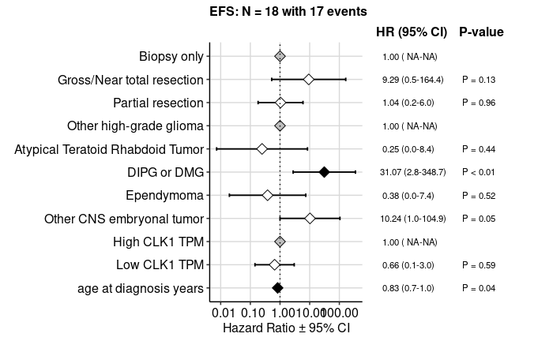

```r
add_model_c6_efs <- fit_save_model(cluster6_df %>%
                                      dplyr::filter(extent_of_tumor_resection != "Unavailable",
                                                    CLK1_TPM_group %in% c("High CLK1 TPM", "Low CLK1 TPM")) %>%
                                      dplyr::mutate(Histology = fct_relevel(Histology,
                                                                            c("Other high-grade glioma", "Atypical Teratoid Rhabdoid Tumor",
                                                                              "DIPG or DMG", "Ependymoma", "Mesenchymal tumor",
                                                                              "Other CNS embryonal tumor", "Low-grade glioma"))),
                              terms = "extent_of_tumor_resection+age_at_diagnosis_years+Histology+CLK1_TPM_group",
                               file.path(results_dir, "cox_EFS_additive_terms_subtype_cluster_clk1_tpm_group.RDS"),
                               "multivariate",
                               years_col = "EFS_years",
                               status_col = "EFS_status")
forest_c6_clk1_efs <- plotForest(readRDS(file.path(results_dir, "cox_EFS_additive_terms_subtype_cluster_clk1_tpm_group.RDS")))
ggsave(file.path(plot_dir, "forest_add_EFS_cluster6_histology_resection_clk1_tpm_group.pdf"),
       forest_c6_clk1_efs,
       width = 9, height = 4, units = "in",
       device = "pdf")
```

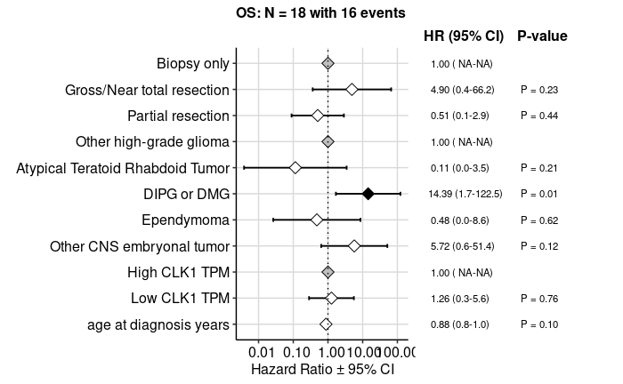

```r
add_model_c6_os <- fit_save_model(cluster6_df %>%
                                    dplyr::filter(!extent_of_tumor_resection %in% c("Not Reported", "Unavailable")) %>%
                                    dplyr::mutate(Histology = fct_relevel(Histology,
                                                                            c("Other high-grade glioma", "Atypical Teratoid Rhabdoid Tumor",
                                                                              "DIPG or DMG", "Ependymoma", "Mesenchymal tumor",
                                                                              "Other CNS embryonal tumor", "Low-grade glioma"))),
                              terms = "extent_of_tumor_resection+age_at_diagnosis_years+Histology+CLK1_TPM_group",
                               file.path(results_dir, "cox_OS_additive_terms_subtype_cluster_clk1_tpm_group.RDS"),
                               "multivariate",
                               years_col = "OS_years",
                               status_col = "OS_status")

forest_c6_clk1_os <- plotForest(readRDS(file.path(results_dir, "cox_OS_additive_terms_subtype_cluster_clk1_tpm_group.RDS")))
ggsave(file.path(plot_dir, "forest_add_OS_cluster6_histology_resection_clk1_tpm_group.pdf"),
       forest_c6_clk1_os,
       width = 9, height = 4, units = "in",
       device = "pdf")
```

Assess EFS and OS by CLK1 PSI group in multivariate models and generate forest plots

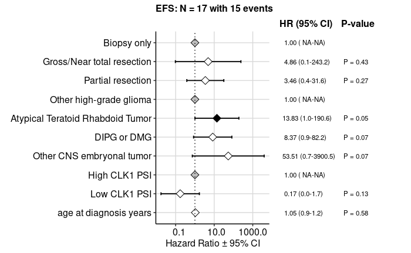

```r
add_model_c6_efs <- fit_save_model(cluster6_df %>%
                                      dplyr::filter(extent_of_tumor_resection != "Unavailable",
                                                    CLK1_PSI_group %in% c("High CLK1 PSI", "Low CLK1 PSI")) %>%
                                      dplyr::mutate(Histology = fct_relevel(Histology,
                                                                            c("Other high-grade glioma", "Atypical Teratoid Rhabdoid Tumor",
                                                                              "DIPG or DMG", "Ependymoma", "Mesenchymal tumor",
                                                                              "Other CNS embryonal tumor", "Low-grade glioma"))),
                              terms = "extent_of_tumor_resection+age_at_diagnosis_years+Histology+CLK1_PSI_group",
                               file.path(results_dir, "cox_EFS_additive_terms_subtype_cluster_clk1_psi_group.RDS"),
                               "multivariate",
                               years_col = "EFS_years",
                               status_col = "EFS_status")
forest_c6_clk1_efs <- plotForest(readRDS(file.path(results_dir, "cox_EFS_additive_terms_subtype_cluster_clk1_psi_group.RDS")))
ggsave(file.path(plot_dir, "forest_add_EFS_cluster6_histology_resection_clk1_psi_group.pdf"),
       forest_c6_clk1_efs,
       width = 9, height = 4, units = "in",
       device = "pdf")
```

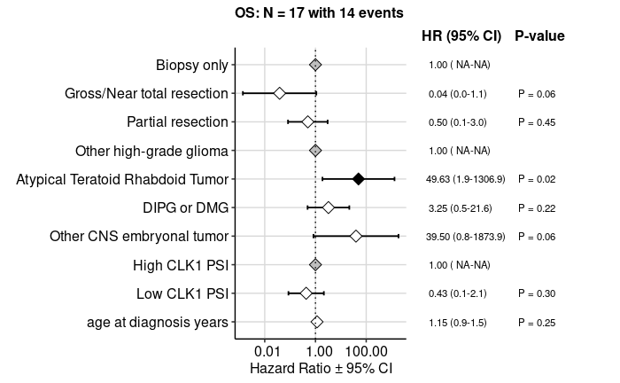

```r
add_model_c6_os <- fit_save_model(cluster6_df %>%
                                    dplyr::filter(!extent_of_tumor_resection %in% c("Not Reported", "Unavailable")) %>%
                                    dplyr::mutate(Histology = fct_relevel(Histology,
                                                                            c("Other high-grade glioma", "Atypical Teratoid Rhabdoid Tumor",
                                                                              "DIPG or DMG", "Ependymoma", "Mesenchymal tumor",
                                                                              "Other CNS embryonal tumor", "Low-grade glioma"))),
                              terms = "extent_of_tumor_resection+age_at_diagnosis_years+Histology+CLK1_PSI_group",
                               file.path(results_dir, "cox_OS_additive_terms_subtype_cluster_clk1_psi_group.RDS"),
                               "multivariate",
                               years_col = "OS_years",
                               status_col = "OS_status")
forest_c6_clk1_os <- plotForest(readRDS(file.path(results_dir, "cox_OS_additive_terms_subtype_cluster_clk1_psi_group.RDS")))
ggsave(file.path(plot_dir, "forest_add_OS_cluster6_histology_resection_clk1_psi_group.pdf"),
       forest_c6_clk1_os,
       width = 9, height = 4, units = "in",
       device = "pdf")
```

Assess EFS and OS by CLK1 ex 4 TPM in multivariate models and generate forest plots

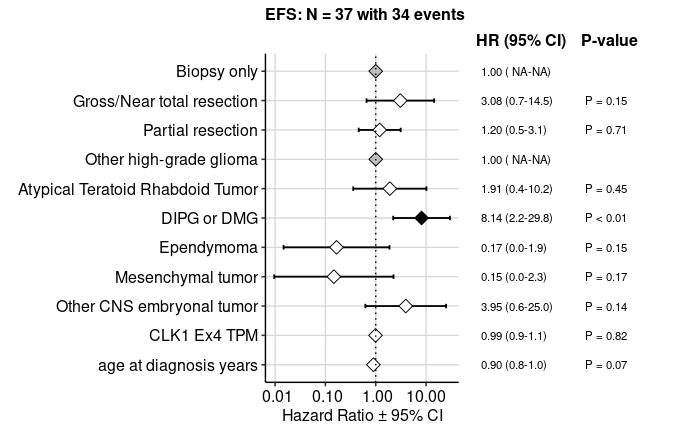

```r
add_model_c6_efs <- fit_save_model(cluster6_df %>%
                                      dplyr::filter(extent_of_tumor_resection != "Unavailable") %>%
                                      dplyr::mutate(Histology = fct_relevel(Histology,
                                                                            c("Other high-grade glioma", "Atypical Teratoid Rhabdoid Tumor",
                                                                              "DIPG or DMG", "Ependymoma", "Mesenchymal tumor",
                                                                              "Other CNS embryonal tumor", "Low-grade glioma"))),
                              terms = "extent_of_tumor_resection+age_at_diagnosis_years+Histology+CLK1_Ex4_TPM",
                               file.path(results_dir, "cox_EFS_additive_terms_subtype_cluster_clk1_tpm.RDS"),
                               "multivariate",
                               years_col = "EFS_years",
                               status_col = "EFS_status")
forest_c6_clk1_efs <- plotForest(readRDS(file.path(results_dir, "cox_EFS_additive_terms_subtype_cluster_clk1_tpm.RDS")))
ggsave(file.path(plot_dir, "forest_add_EFS_cluster6_histology_resection_clk1_tpm.pdf"),
       forest_c6_clk1_efs,
       width = 9, height = 4, units = "in",
       device = "pdf")
```

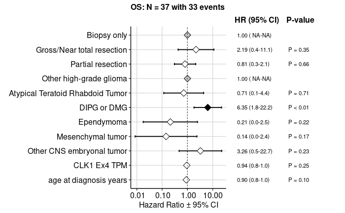

```r
add_model_c6_os <- fit_save_model(cluster6_df %>%
                                    dplyr::filter(!extent_of_tumor_resection %in% c("Not Reported", "Unavailable")) %>%
                                    dplyr::mutate(Histology = fct_relevel(Histology,
                                                                            c("Other high-grade glioma", "Atypical Teratoid Rhabdoid Tumor",
                                                                              "DIPG or DMG", "Ependymoma", "Mesenchymal tumor",
                                                                              "Other CNS embryonal tumor", "Low-grade glioma"))),
                              terms = "extent_of_tumor_resection+age_at_diagnosis_years+Histology+CLK1_Ex4_TPM",
                               file.path(results_dir, "cox_OS_additive_terms_subtype_cluster_clk1_tpm.RDS"),
                               "multivariate",
                               years_col = "OS_years",
                               status_col = "OS_status")
forest_c6_clk1_os <- plotForest(readRDS(file.path(results_dir, "cox_OS_additive_terms_subtype_cluster_clk1_tpm.RDS")))
ggsave(file.path(plot_dir, "forest_add_OS_cluster6_histology_resection_clk1_tpm.pdf"),
       forest_c6_clk1_os,
       width = 9, height = 4, units = "in",
       device = "pdf")
```

Assess EFS and OS by CLK1 ex 4 PSI in multivariate models and generate forest plots

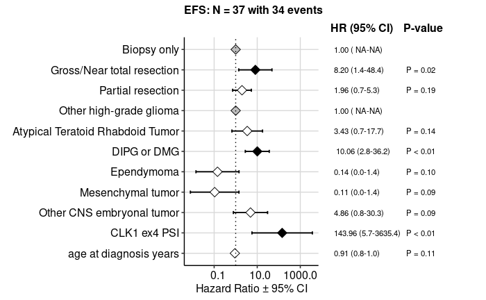

```r
add_model_c6_efs <- fit_save_model(cluster6_df %>%
                                      dplyr::filter(extent_of_tumor_resection != "Unavailable") %>%
                                      dplyr::mutate(Histology = fct_relevel(Histology,
                                                                            c("Other high-grade glioma", "Atypical Teratoid Rhabdoid Tumor",
                                                                              "DIPG or DMG", "Ependymoma", "Mesenchymal tumor",
                                                                              "Other CNS embryonal tumor", "Low-grade glioma"))),
                              terms = "extent_of_tumor_resection+age_at_diagnosis_years+Histology+CLK1_ex4_PSI",
                               file.path(results_dir, "cox_EFS_additive_terms_subtype_cluster_clk1_psi.RDS"),
                               "multivariate",
                               years_col = "EFS_years",
                               status_col = "EFS_status")
forest_c6_clk1_efs <- plotForest(readRDS(file.path(results_dir, "cox_EFS_additive_terms_subtype_cluster_clk1_psi.RDS")))
ggsave(file.path(plot_dir, "forest_add_EFS_cluster6_histology_resection_clk1_psi.pdf"),
       forest_c6_clk1_efs,
       width = 9, height = 4, units = "in",
       device = "pdf")
```

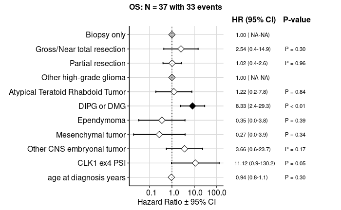

```r
add_model_c6_os <- fit_save_model(cluster6_df %>%
                                    dplyr::filter(!extent_of_tumor_resection %in% c("Not Reported", "Unavailable")) %>%
                                    dplyr::mutate(Histology = fct_relevel(Histology,
                                                                            c("Other high-grade glioma", "Atypical Teratoid Rhabdoid Tumor",
                                                                              "DIPG or DMG", "Ependymoma", "Mesenchymal tumor",
                                                                              "Other CNS embryonal tumor", "Low-grade glioma"))),
                              terms = "extent_of_tumor_resection+age_at_diagnosis_years+Histology+CLK1_ex4_PSI",
                               file.path(results_dir, "cox_OS_additive_terms_subtype_cluster_clk1_psi.RDS"),
                               "multivariate",
                               years_col = "OS_years",
                               status_col = "OS_status")
forest_c6_clk1_os <- plotForest(readRDS(file.path(results_dir, "cox_OS_additive_terms_subtype_cluster_clk1_psi.RDS")))
ggsave(file.path(plot_dir, "forest_add_OS_cluster6_histology_resection_clk1_psi.pdf"),
       forest_c6_clk1_os,
       width = 9, height = 4, units = "in",
       device = "pdf")
```